# Travel Barriers Bar Plots

Below are a few exploratory stacked percent charts generated from a survey on travel barriers of Syrian refugees in Durham region (Canada). Plots were built using ggplot2 and Rmarkdown sometime during the summer of 2017 - **[*Jeff Allen*](http://jamaps.github.io/)**

**[Click here for a detailed research paper regarding this project](https://www.sciencedirect.com/science/article/abs/pii/S096669231730594X)**

### Survey Summary

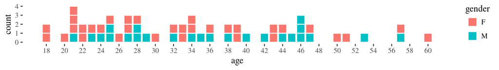

In the last few months, how often did you use the following modes of transportation?

never 0-1 days/week 2-3 days/week 4-5 days/week 6-7 days/week

Walk

Public Transit

Car as Passegner

Car as Driver

Taxi

Bike

### Barriers to Mode Use

On a scale of 1 to 5, to what degree do each of the following prevent you from using public transportation?

3.2 weather conditions

3.1 cost

3.0 transit unavailable when needed

2.9 lack of route/schedule knowledge

2.8 waiting time too long

2.7 takes too long to reach destination

2.7 poorly timed transfers

2.6 too many transfers

2.5 need to carry heavy loads

2.3 no bus stop near destination

2.2 no bus stop near home

2.2 can’t ask for help

2.0 understanding transit maps

= 1, = 2, = 3, = 4, = 5

*Where (1) means, “This does not prevent me”, (3) means “This sometimes prevents me”, and (5) means, “This completely prevents me”*

On a scale of 1 to 5, to what degree do each of the following prevent you from driving?

4.3 cost for maintaining a car

4.0 cost for puchasing a car

2.9 obtaining a driver’s license

2.3 navigation and knowing the roads

2.1 never driven before

2.1 weather conditions

2.1 getting used to Canadian driving rules

1.5 safety

= 1, = 2, = 3, = 4, = 5

*Where (1) means, “This does not prevent me”, (3) means “This sometimes prevents me”, and (5) means, “This completely prevents me”*

On a scale of 1 to 5, to what degree do each of the following prevent you from cycling?

3.2 weather conditions

3.0 destinations too far away for biking

2.8 traffic speed too high

2.8 cost of purchasing a bike

2.7 too many cars on the road

2.6 need to carry passengers or heavy loads

2.5 knowledge of routes

2.5 nowhere to safely store bike at destination

2.4 safety

2.4 knowledge of cycling rules

2.3 few other people ride bikes here

2.3 lack of cycling lanes

2.2 knowing how to ride a bike

2.2 poor health or fitness

2.1 clothing gets in the way

2.0 nowhere to safely store bike at home

= 1, = 2, = 3, = 4, = 5

*Where (1) means, “This does not prevent me”, (3) means “This sometimes prevents me”, and (5) means, “This completely prevents me”*

On a scale of 1 to 5, to what degree do each of the following prevent you from walking?

3.7 destinations too far away

3.5 weather conditions

3.3 need to carry heavy loads

1.9 knowledge of routes

1.9 safety & crime

1.8 physical capabilities

= 1, = 2, = 3, = 4, = 5

*Where (1) means, “This does not prevent me”, (3) means “This sometimes prevents me”, and (5) means, “This completely prevents me”*

On a scale of 1 to 5, to what degree do each of the following prevent you from carpooling?

3.5 difficult to ask for help

3.4 difficult to coordinate

3.0 drivers dont live nearby

3.0 drivers dont go where I want to go

2.7 nobody to carpool with

2.4 safety / trust

= 1, = 2, = 3, = 4, = 5

*Where (1) means, “This does not prevent me”, (3) means “This sometimes prevents me”, and (5) means, “This completely prevents me”*

#### Activity Participation:

In the past few months, how often have you participated in the following activities:

1.1 language classes

1.8 children’s school or daycare

1.9 adult education

2.0 grocery store

3.0 culturally specific grocery store

3.1 mosque / other place of worship

3.4 visiting friends or family

3.4 gym / fitness

3.8 family doctor

3.8 recreation activities

= 1 = daily = 2 = a few times per week = 3 = a few times per month

= 4 = once per month = 5 = less than once per month / never = N/A did not answer

By your most frequent mode of travel, how long does it typically take you to travel (one-way) to each of these activities?

3.1 culturally specific grocery store

2.8 mosque / other place of worship

2.7 recreation activities

2.6 visiting friends or family

2.3 family doctor

2.2 grocery store

2.0 gym / fitness

2.0 language classes

2.0 adult education

1.7 children’s school or daycare

= 1 = 0-15 minutes = 2 = 15-30 minutes = 3 = 30-45 minutes

= 4 = 45-60 minutes = 5 = 60+ minutes N/A were removed prior to plotting

I am currently doing the following activities as often as I would like:

3.2 grocery store

3.2 recreation activities

3.4 vistiing friends or family

3.6 gym / fitness

3.6 culturally specific grocery store

3.7 children’s school or daycare

3.7 mosque / other place of worship

3.7 family doctor

3.7 adult education

4.0 language classes

= 1 = Strongly Disagree = 2 = Disagree = 3 = Neutral = 4 = Agree = 5 = Strongly Agree = N/A

Is transportation a barrier to participating as often as you would like in the following activities:

3.5 visiting friends or family

3.5 recreation activities

3.3 mosque / other place of worship

3.3 culturally specific grocery store

2.7 grocery store

2.7 gym / fitness

2.6 family doctor

2.5 language classes

2.5 adult education

2.4 children’s school or daycare

= 1 = 2 = 3 = 4 = 5 = N/A

*where (1) means, “Transportation is not at all a barrier to participation”*

*and (5) means, “Transportation is a very strong barrier to participation”.*

##### Well-Being

How does your transportation situation affect the following aspects of your well-being?

2.1 loneliness

2.1 boredom

2.2 sadness

2.7 sense of belonging

2.8 engagement in activities

2.9 satisfaction with life

3.0 self-esteem and confidence

3.1 physical health

= 1 = much worse = 2 = worse = 3 = no impact = 4 = better = 5 = much better